# EricFriesth_hw3

Eric Friesth

10/15/2019

## Homework 3

## https://github.com/ericf8/ds202_hw3

```r
data(flights,package="nycflights13")

LongDelay = subset(flights, flights$arr_delay >= 200)
head(LongDelay)
```

```
##     year month day dep_time sched_dep_time dep_delay arr_time
## 152 2013     1   1      848           1835       853     1001
## 650 2013     1   1     1815           1325       290     2120
## 674 2013     1   1     1842           1422       260     1958
## 747 2013     1   1     2006           1630       216     2230
## 802 2013     1   1     2115           1700       255     2330
## 816 2013     1   1     2205           1720       285       46
##     sched_arr_time arr_delay carrier flight tailnum origin dest air_time
## 152           1950       851      MQ   3944  N942MQ    JFK  BWI       41
## 650           1542       338      EV   4417  N17185    EWR  OMA      213
## 674           1535       263      EV   4633  N18120    EWR  BTV       46
## 747           1848       222      EV   4644  N14972    EWR  SAV      121
## 802           1920       250      9E   3347  N924XJ    JFK  CVG      115
## 816           2040       246      AA   1999  N5DNAA    EWR  MIA      146
##     distance hour minute           time_hour
## 152      184   18     35 2013-01-01 18:00:00
## 650     1134   13     25 2013-01-01 13:00:00
## 674      266   14     22 2013-01-01 14:00:00
## 747      708   16     30 2013-01-01 16:00:00
## 802      589   17      0 2013-01-01 17:00:00
## 816     1085   17     20 2013-01-01 17:00:00
```

1b. Flew to Houston (IAH or HOU)

```r
HoustonFlights = subset(flights, flights$dest == "IAH" | flights$dest == "HOU")
head(HoustonFlights)
```

```
##     year month day dep_time sched_dep_time dep_delay arr_time
## 1   2013     1   1      517            515         2      830
## 2   2013     1   1      533            529         4      850
## 33  2013     1   1      623            627        -4      933
## 82  2013     1   1      728            732        -4     1041
## 90  2013     1   1      739            739         0     1104
## 178 2013     1   1      908            908         0     1228
##     sched_arr_time arr_delay carrier flight tailnum origin dest air_time
## 1              819        11      UA   1545  N14228    EWR  IAH      227
## 2              830        20      UA   1714  N24211    LGA  IAH      227
## 33             932         1      UA    496  N459UA    LGA  IAH      229
## 82            1038         3      UA    473  N488UA    LGA  IAH      238
## 90            1038        26      UA   1479  N37408    EWR  IAH      249
## 178           1219         9      UA   1220  N12216    EWR  IAH      233
##     distance hour minute           time_hour
## 1       1400    5     15 2013-01-01 05:00:00
## 2       1416    5     29 2013-01-01 05:00:00
## 33      1416    6     27 2013-01-01 06:00:00
## 82      1416    7     32 2013-01-01 07:00:00
## 90      1400    7     39 2013-01-01 07:00:00
## 178     1400    9      8 2013-01-01 09:00:00
```

1c. Departed in summer months (July, August, September)

```r
SummerDepart = subset(flights, flights$month == 7 | flights$month == 8 | flights$month == 9)
head(SummerDepart)
```

```
##        year month day dep_time sched_dep_time dep_delay arr_time
## 250451 2013     7   1        1           2029       212      236
## 250452 2013     7   1        2           2359         3      344
## 250453 2013     7   1       29           2245       104      151
## 250454 2013     7   1       43           2130       193      322
## 250455 2013     7   1       44           2150       174      300
## 250456 2013     7   1       46           2051       235      304
##        sched_arr_time arr_delay carrier flight tailnum origin dest
## 250451           2359       157      B6    915  N653JB    JFK  SFO
## 250452            344         0      B6   1503  N805JB    JFK  SJU
## 250453              1       110      B6    234  N348JB    JFK  BTV
## 250454             14       188      B6   1371  N794JB    LGA  FLL
## 250455            100       120      AA    185  N324AA    JFK  LAX
## 250456           2358       186      B6    165  N640JB    JFK  PDX
##        air_time distance hour minute           time_hour
## 250451      315     2586   20     29 2013-07-01 20:00:00
## 250452      200     1598   23     59 2013-07-01 23:00:00
## 250453       66      266   22     45 2013-07-01 22:00:00
## 250454      143     1076   21     30 2013-07-01 21:00:00
## 250455      297     2475   21     50 2013-07-01 21:00:00
## 250456      304     2454   20     51 2013-07-01 20:00:00
```

1d. Arrived more than two hours late, but didn’t leave late

```r
LongDelay2 = subset(flights, flights$dep_delay <= 0 & flights$arr_delay >= 120)
head(LongDelay2)
```

```
##        year month day dep_time sched_dep_time dep_delay arr_time
## 22912  2013     1  27     1419           1420        -1     1754
## 33012  2013    10   7     1350           1350         0     1736
## 33020  2013    10   7     1357           1359        -2     1858
## 41076  2013    10  16      657            700        -3     1258
## 55986  2013    11   1      658            700        -2     1329
## 152767 2013     3  18     1844           1847        -3       39
##        sched_arr_time arr_delay carrier flight tailnum origin dest
## 22912            1550       124      MQ   3728  N1EAMQ    EWR  ORD
## 33012            1526       130      EV   5181  N611QX    LGA  MSN
## 33020            1654       124      AA   1151  N3CMAA    LGA  DFW
## 41076            1056       122      B6      3  N703JB    JFK  SJU
## 55986            1015       194      VX    399  N629VA    JFK  LAX
## 152767           2219       140      UA    389  N560UA    JFK  SFO
##        air_time distance hour minute           time_hour
## 22912       135      719   14     20 2013-01-27 14:00:00
## 33012       117      812   13     50 2013-10-07 13:00:00
## 33020       192     1389   13     59 2013-10-07 13:00:00
## 41076       225     1598    7      0 2013-10-16 07:00:00
## 55986       336     2475    7      0 2013-11-01 07:00:00
## 152767      386     2586   18     47 2013-03-18 18:00:00
```

1e. Were delayed by at least an hour, but made up over 30 minutes in flight

```r
QuickFlight = subset(flights, flights$dep_delay >= 60 & flights$dep_delay - flights$arr_delay > 30)
head(QuickFlight)
```

```
##      year month day dep_time sched_dep_time dep_delay arr_time
## 816  2013     1   1     2205           1720       285       46
## 833  2013     1   1     2326           2130       116      131
## 2287 2013     1   3     1503           1221       162     1803
## 2509 2013     1   3     1839           1700        99     2056
## 2523 2013     1   3     1850           1745        65     2148
## 2572 2013     1   3     1941           1759       102     2246
##      sched_arr_time arr_delay carrier flight tailnum origin dest air_time
## 816            2040       246      AA   1999  N5DNAA    EWR  MIA      146
## 833              18        73      B6    199  N594JB    JFK  LAS      290
## 2287           1555       128      UA    551  N835UA    EWR  SFO      320
## 2509           1950        66      AA    575  N631AA    JFK  EGE      239
## 2523           2120        28      AA    177  N332AA    JFK  SFO      314
## 2572           2139        67      UA    979  N402UA    EWR  PHX      274
##      distance hour minute           time_hour
## 816      1085   17     20 2013-01-01 17:00:00
## 833      2248   21     30 2013-01-01 21:00:00
## 2287     2565   12     21 2013-01-03 12:00:00
## 2509     1747   17      0 2013-01-03 17:00:00
## 2523     2586   17     45 2013-01-03 17:00:00
## 2572     2133   17     59 2013-01-03 17:00:00
```

2. This definition of cancelled flights isn’t optimal because it will show you a large array of ‘True’s and ’False’s as this operation is just testing for logic. The most import column for finding cancelled flights would be ’dep_delay’ or Departure Delay as a plane that has left the airport is considered a “flight.”

```r
cancelledFlights = is.na(flights$dep_delay) | is.na(flights$arr_delay)
head(cancelledFlights)
```

```
## [1] FALSE FALSE FALSE FALSE FALSE FALSE
```

3. According to the distribution below containing flights that don’t have delays grouped by hour, the best time to fly would be between the times of 5:00am and 10:00am.

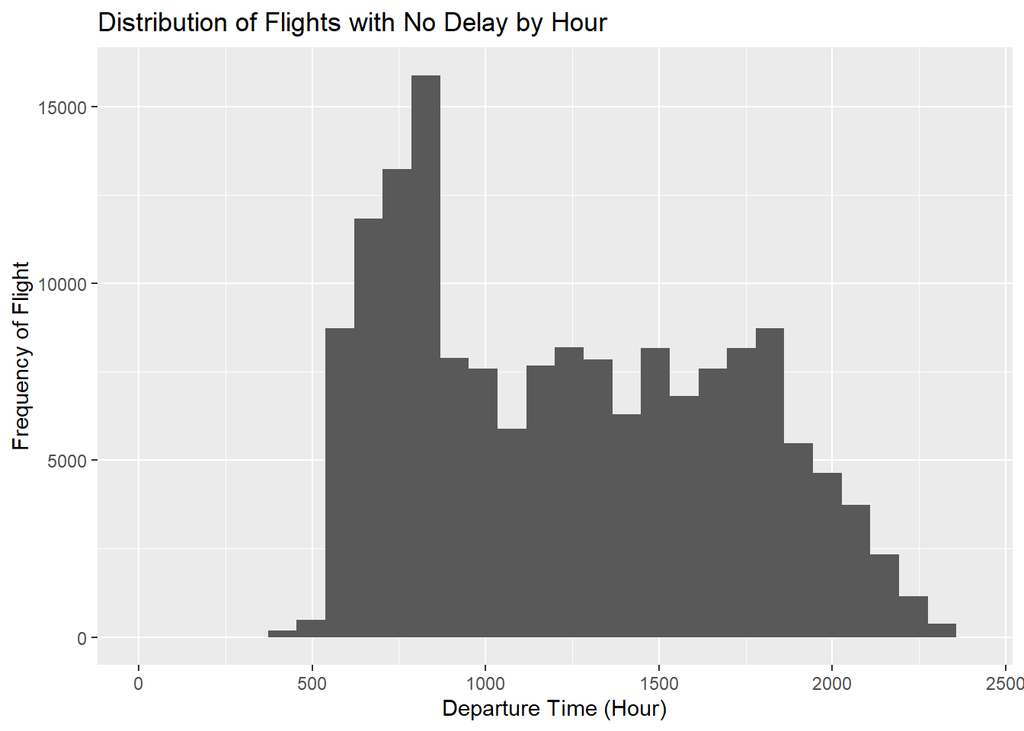

```r
library(ggplot2)

zeroDelay = subset(flights, flights$dep_delay <= 0 & flights$arr_delay <= 0) #created a subset of flights containing only flights with 0 delay or early departures/arrivals

ggplot(zeroDelay, aes(x = zeroDelay$dep_time, group = zeroDelay$hour, bins = 24)) + geom_histogram() + labs(title = "Distribution of Flights with No Delay by Hour", x = "Departure Time (Hour)", y = "Frequency of Flight") + scale_x_continuous(limits=c(0, 2400))
```

```r
data(airlines,package='nycflights13')
data(airports,package='nycflights13')
data(planes,package='nycflights13')
data(weather,package='nycflights13')
```

```r
library(nycflights13)
#?airports
```

```r
library(dplyr)
library(tidyverse)
flight_weather =
flights %>%
inner_join(weather, by = c(
  "origin" = "origin",
  "year" = "year",
  "month" = "month",
  "day" = "day",
  "hour" = "hour"
 ))

head(flight_weather)
```

```
## # A tibble: 6 x 29
##    year month   day dep_time sched_dep_time dep_delay arr_time
##   <int> <int> <int>    <int>          <int>     <dbl>    <int>
## 1  2013     1     1      517            515         2      830
## 2  2013     1     1      533            529         4      850
## 3  2013     1     1      542            540         2      923
## 4  2013     1     1      544            545        -1     1004
## 5  2013     1     1      554            600        -6      812
## 6  2013     1     1      554            558        -4      740
## # ... with 22 more variables: sched_arr_time <int>, arr_delay <dbl>,
## #   carrier <chr>, flight <int>, tailnum <chr>, origin <chr>, dest <chr>,
## #   air_time <dbl>, distance <dbl>, hour <dbl>, minute <dbl>,
## #   time_hour.x <dttm>, temp <dbl>, dewp <dbl>, humid <dbl>,
## #   wind_dir <dbl>, wind_speed <dbl>, wind_gust <dbl>, precip <dbl>,
## #   pressure <dbl>, visib <dbl>, time_hour.y <dttm>
```

```r
weatherDelays = filter(flight_weather, (dep_delay > 60) | (arr_delay) > 60)

head(weatherDelays)
```

```
## # A tibble: 6 x 29
##    year month   day dep_time sched_dep_time dep_delay arr_time
##   <int> <int> <int>    <int>          <int>     <dbl>    <int>
## 1  2013     1     1      811            630       101     1047
## 2  2013     1     1      826            715        71     1136
## 3  2013     1     1      848           1835       853     1001
## 4  2013     1     1      957            733       144     1056
## 5  2013     1     1     1114            900       134     1447
## 6  2013     1     1     1120            944        96     1331
## # ... with 22 more variables: sched_arr_time <int>, arr_delay <dbl>,
## #   carrier <chr>, flight <int>, tailnum <chr>, origin <chr>, dest <chr>,
## #   air_time <dbl>, distance <dbl>, hour <dbl>, minute <dbl>,
## #   time_hour.x <dttm>, temp <dbl>, dewp <dbl>, humid <dbl>,
## #   wind_dir <dbl>, wind_speed <dbl>, wind_gust <dbl>, precip <dbl>,
## #   pressure <dbl>, visib <dbl>, time_hour.y <dttm>
```

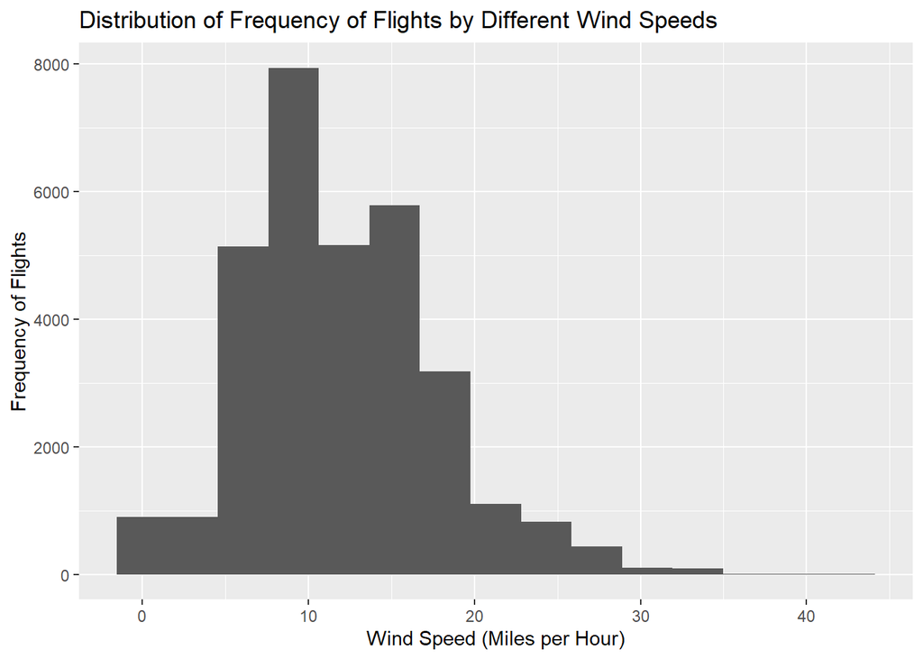

```r
ggplot(weatherDelays, aes(x = weatherDelays$wind_speed)) + geom_histogram(bins = 15) + labs(title = "Distribution of Frequency of Flights by Different Wind Speeds", x = "Wind Speed (Miles per Hour)", y = "Frequency of Flights")
```

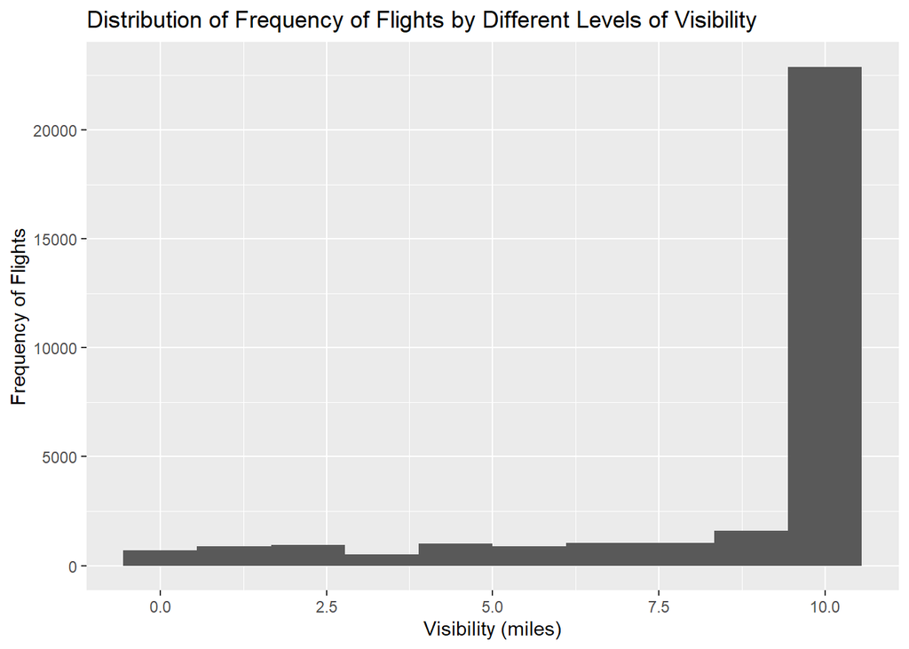

```r
ggplot(weatherDelays, aes(x = weatherDelays$visib)) + geom_histogram(bins = 10) + labs(title = "Distribution of Frequency of Flights by Different Levels of Visibility", x = "Visibility (miles)", y = "Frequency of Flights")
```

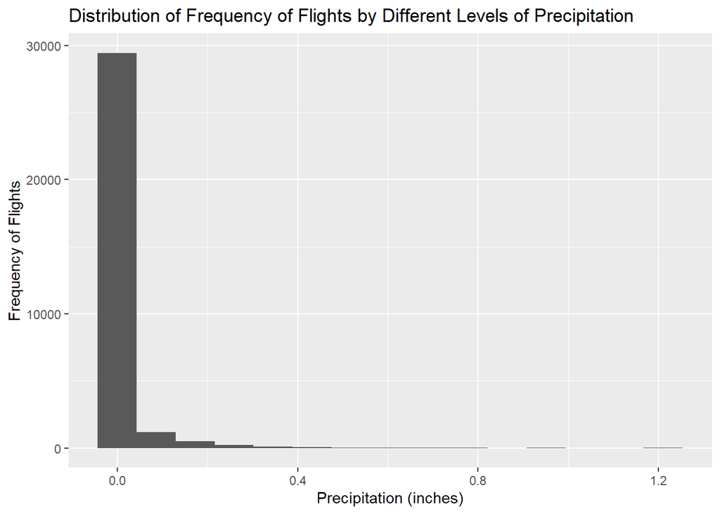

```r
ggplot(weatherDelays, aes(x = weatherDelays$precip)) + geom_histogram(bins = 15) + labs(title = "Distribution of Frequency of Flights by Different Levels of Precipitation", x = "Precipitation (inches)", y = "Frequency of Flights")
```

7. Using the function INNER_JOIN on two datasets returns the rows when there’s match ups in those datasets while the function LEFT_JOIN returns all the observations from the left dataset even if they aren’t found matched up in the other dataset.

```r
flight_weather_left =
flights %>%
left_join(weather, by = c(
  "origin" = "origin",
  "year" = "year",
  "month" = "month",
  "day" = "day",
  "hour" = "hour"
 ))

head(flight_weather_left)
```

```
## # A tibble: 6 x 29
##    year month   day dep_time sched_dep_time dep_delay arr_time
##   <int> <int> <int>    <int>          <int>     <dbl>    <int>
## 1  2013     1     1      517            515         2      830
## 2  2013     1     1      533            529         4      850
## 3  2013     1     1      542            540         2      923
## 4  2013     1     1      544            545        -1     1004
## 5  2013     1     1      554            600        -6      812
## 6  2013     1     1      554            558        -4      740
## # ... with 22 more variables: sched_arr_time <int>, arr_delay <dbl>,
## #   carrier <chr>, flight <int>, tailnum <chr>, origin <chr>, dest <chr>,
## #   air_time <dbl>, distance <dbl>, hour <dbl>, minute <dbl>,
## #   time_hour.x <dttm>, temp <dbl>, dewp <dbl>, humid <dbl>,
## #   wind_dir <dbl>, wind_speed <dbl>, wind_gust <dbl>, precip <dbl>,
## #   pressure <dbl>, visib <dbl>, time_hour.y <dttm>
```

```r
weatherDelays_left = filter(flight_weather_left, (dep_delay > 60) | (arr_delay) > 60)

head(weatherDelays_left)
```

```
## # A tibble: 6 x 29
##    year month   day dep_time sched_dep_time dep_delay arr_time
##   <int> <int> <int>    <int>          <int>     <dbl>    <int>
## 1  2013     1     1      811            630       101     1047
## 2  2013     1     1      826            715        71     1136
## 3  2013     1     1      848           1835       853     1001
## 4  2013     1     1      957            733       144     1056
## 5  2013     1     1     1114            900       134     1447
## 6  2013     1     1     1120            944        96     1331
## # ... with 22 more variables: sched_arr_time <int>, arr_delay <dbl>,
## #   carrier <chr>, flight <int>, tailnum <chr>, origin <chr>, dest <chr>,
## #   air_time <dbl>, distance <dbl>, hour <dbl>, minute <dbl>,
## #   time_hour.x <dttm>, temp <dbl>, dewp <dbl>, humid <dbl>,
## #   wind_dir <dbl>, wind_speed <dbl>, wind_gust <dbl>, precip <dbl>,
## #   pressure <dbl>, visib <dbl>, time_hour.y <dttm>
```

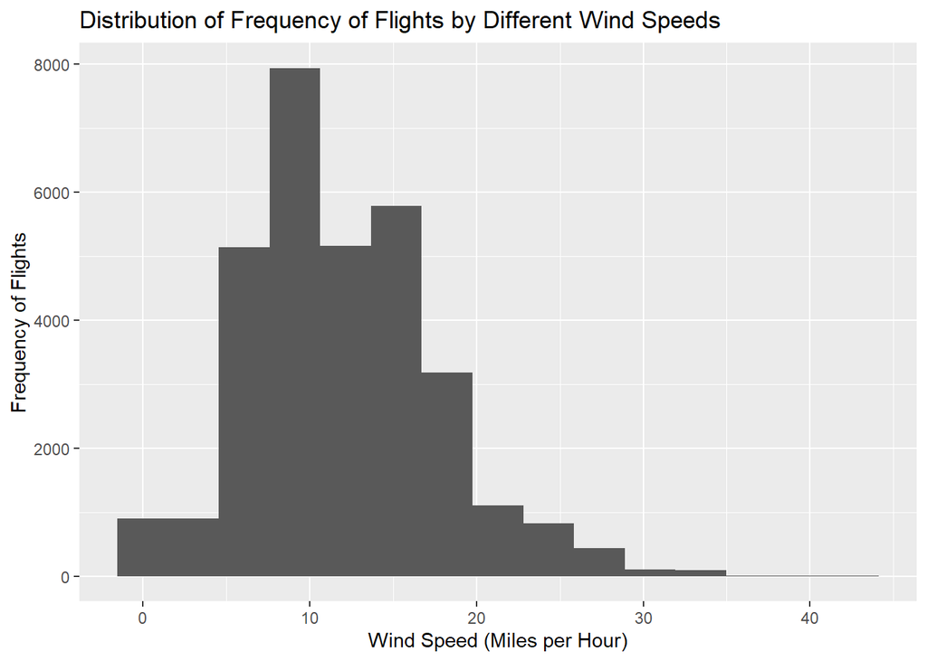

```r
ggplot(weatherDelays_left, aes(x = weatherDelays_left$wind_speed)) + geom_histogram(bins = 15) + labs(title = "Distribution of Frequency of Flights by Different Wind Speeds", x = "Wind Speed (Miles per Hour)", y = "Frequency of Flights")
```

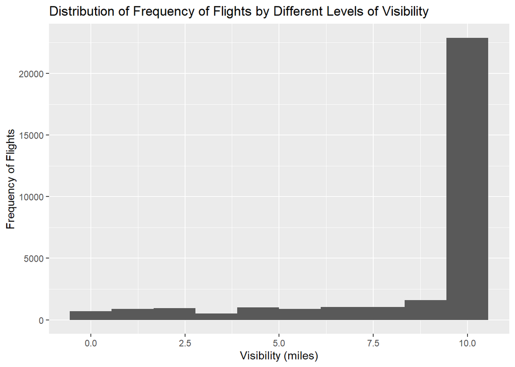

```r
ggplot(weatherDelays_left, aes(x = weatherDelays_left$visib)) + geom_histogram(bins = 10) + labs(title = "Distribution of Frequency of Flights by Different Levels of Visibility", x = "Visibility (miles)", y = "Frequency of Flights")
```

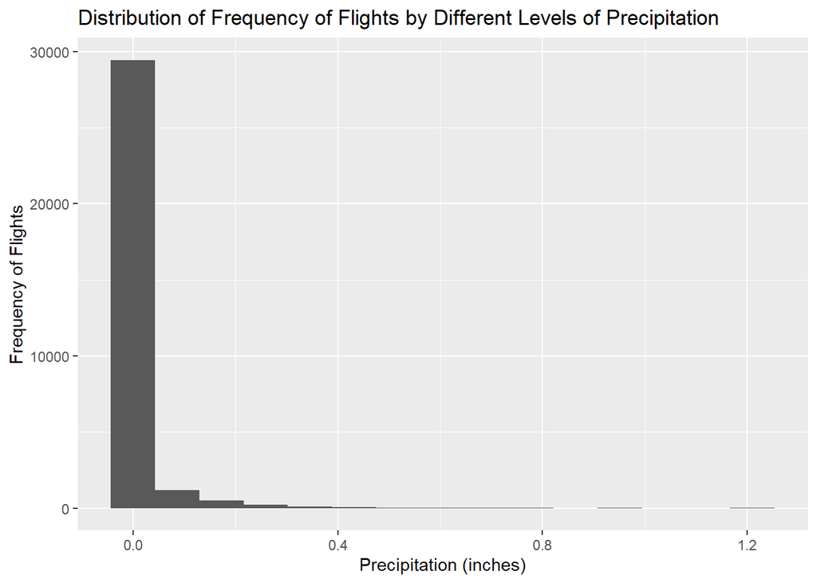

```r
ggplot(weatherDelays_left, aes(x = weatherDelays_left$precip)) + geom_histogram(bins = 15) + labs(title = "Distribution of Frequency of Flights by Different Levels of Precipitation", x = "Precipitation (inches)", y = "Frequency of Flights")
```

8. Using the scatter plot below, I see that there isn’t an overwhelming correlation between the age of a plane and departure delays but we do see more incidents of total flights in planes younger than 40.

```r
planes = mutate(planes, "age" = 2019 - planes$year)

flights_planes =
  planes %>%
  inner_join(flights, by = c(
    "tailnum" = "tailnum"
  ))

head(flights_planes)
```

```
## # A tibble: 6 x 28
##   tailnum year.x type  manufacturer model engines seats speed engine   age
##   <chr>    <int> <chr> <chr>        <chr>   <int> <int> <int> <chr>  <dbl>
## 1 N10156    2004 Fixe~ EMBRAER      EMB-~       2    55    NA Turbo~    15
## 2 N10156    2004 Fixe~ EMBRAER      EMB-~       2    55    NA Turbo~    15
## 3 N10156    2004 Fixe~ EMBRAER      EMB-~       2    55    NA Turbo~    15
## 4 N10156    2004 Fixe~ EMBRAER      EMB-~       2    55    NA Turbo~    15
## 5 N10156    2004 Fixe~ EMBRAER      EMB-~       2    55    NA Turbo~    15
## 6 N10156    2004 Fixe~ EMBRAER      EMB-~       2    55    NA Turbo~    15
## # ... with 18 more variables: year.y <int>, month <int>, day <int>,
## #   dep_time <int>, sched_dep_time <int>, dep_delay <dbl>, arr_time <int>,
## #   sched_arr_time <int>, arr_delay <dbl>, carrier <chr>, flight <int>,
## #   origin <chr>, dest <chr>, air_time <dbl>, distance <dbl>, hour <dbl>,
## #   minute <dbl>, time_hour <dttm>
```

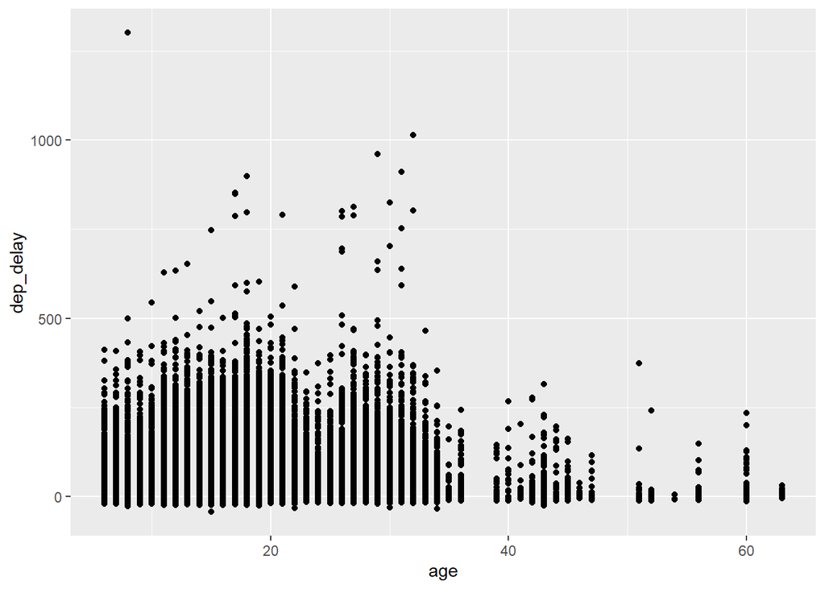

```r
ggplot(flights_planes, aes(x = age, y = dep_delay)) + geom_point() + labs()
```

9. In the first argument, we are shown the flights dataset with the faa from airports connected by dest and in the second, we are shown the airports dataset with the dest of flights connected by faa.

```r
anti_join(flights, airports, by = c("dest" = "faa"))
```

```
## # A tibble: 7,602 x 19
##     year month   day dep_time sched_dep_time dep_delay arr_time
##    <int> <int> <int>    <int>          <int>     <dbl>    <int>
##  1  2013     1     1      544            545        -1     1004
##  2  2013     1     1      615            615         0     1039
##  3  2013     1     1      628            630        -2     1137
##  4  2013     1     1      701            700         1     1123
##  5  2013     1     1      711            715        -4     1151
##  6  2013     1     1      820            820         0     1254
##  7  2013     1     1      820            820         0     1249
##  8  2013     1     1      840            845        -5     1311
##  9  2013     1     1      909            810        59     1331
## 10  2013     1     1      913            918        -5     1346
## # ... with 7,592 more rows, and 12 more variables: sched_arr_time <int>,
## #   arr_delay <dbl>, carrier <chr>, flight <int>, tailnum <chr>,
## #   origin <chr>, dest <chr>, air_time <dbl>, distance <dbl>, hour <dbl>,
## #   minute <dbl>, time_hour <dttm>
```

```r
anti_join(airports, flights, by = c("faa" = "dest"))
```

```
## # A tibble: 1,357 x 8
##    faa   name                    lat    lon   alt    tz dst   tzone
##    <chr> <chr>                 <dbl>  <dbl> <dbl> <dbl> <chr> <chr>
##  1 04G   Lansdowne Airport      41.1  -80.6  1044    -5 A     America/New_~
##  2 06A   Moton Field Municipa~  32.5  -85.7   264    -6 A     America/Chic~
##  3 06C   Schaumburg Regional    42.0  -88.1   801    -6 A     America/Chic~
##  4 06N   Randall Airport        41.4  -74.4   523    -5 A     America/New_~
##  5 09J   Jekyll Island Airport  31.1  -81.4    11    -5 A     America/New_~
##  6 0A9   Elizabethton Municip~  36.4  -82.2  1593    -5 A     America/New_~
##  7 0G6   Williams County Airp~  41.5  -84.5   730    -5 A     America/New_~
##  8 0G7   Finger Lakes Regiona~  42.9  -76.8   492    -5 A     America/New_~
##  9 0P2   Shoestring Aviation ~  39.8  -76.6  1000    -5 U     America/New_~
## 10 0S9   Jefferson County Intl  48.1 -123.    108    -8 A     America/Los_~
## # ... with 1,347 more rows
```